# MET529 - Term Paper (Classification Algorithms to detect human activity)

Anonymous

2024-11-28

# Introduction

Wearable technology has been progressively incorporated into the healthcare sector in recent years, revolutionizing both professional medical practice and personal health monitoring. With applications ranging from illness prevention, rehabilitation, and physical therapy to areas far beyond fitness tracking, devices like Fitbit, Nike FuelBand, and Jawbone Up have made it possible to gather enormous volumes of data on human activities. The quantified self movement, in which people utilize self-monitoring devices to collect comprehensive data about different facets of their lives, is consistent with this trend. Wearable technology has a significant potential impact on the healthcare industry. By enabling the early identification of problems like sedentary behavior, irregular exercise habits, or symptoms associated with chronic illnesses, continuous physical activity monitoring can offer vital insights into an individual’s health status (Rodgers et al., 2019; Piwek et al., 2016). Furthermore, wearable technology can now quantify the quality of activity in addition to activity volume thanks to developments in data analytics, particularly the application of machine learning and classification algorithms. This is a useful application for both health professionals and tech enthusiasts (Mukhopadhyay, 2014; Wang et al., 2005).

Processing and understanding data from wearables could be greatly aided by applied analytics using R, one of the top statistical computing environments, particularly in healthcare settings. Due to its broad ecosystem of machine learning libraries and its strong data manipulation and visualization capabilities, R-based analytics is well regarded and is especially well-suited for tasks involving activity recognition (Wickham, 2019; Kuhn & Johnson, 2019). In this project, accelerometer data obtained from wearable sensors during exercise is analyzed using R’s applied analytics tools. This information, which was gathered from participants’ belts, forearms, arms, and dumbbells while they were executing barbell lifts, offers a chance to investigate classification algorithms that can forecast how these activities will be executed. This project illustrates the use of R for creating predictive models that have immediate uses in healthcare, like remote patient monitoring and customized workout feedback, by distinguishing proper and wrong movements in exercises (Bejarano et al., 2014).

In the medical field, evaluating the quality of an activity is especially helpful for physical therapy and rehabilitation, as proper form is essential to patient recovery and injury prevention. For example, physical therapists may be able to remotely monitor their clients’ compliance with recommended rehabilitation regimens by employing wearable sensors to determine whether the patient is executing exercises correctly. This is especially important in light of the COVID-19 epidemic, which has prompted a rise in the use of remote monitoring tools and telehealth services. R’s classification algorithms have additional potential uses in preventative health, as seeing abnormal movement patterns could help with the early detection of musculoskeletal conditions. The research aims to show how R-based applied analytics may improve health care applications by making it possible to analyze wearable sensor data accurately and meaningfully, laying the groundwork for more individualized and responsive health interventions.

It is now feasible to get a significant quantity of data on personal activity at a reasonable cost by using gadgets like Fitbit, Nike FuelBand, and Jawbone Up. These gadgets are a part of the quantified self movement, which is a group of enthusiasts that measure themselves on a regular basis for a variety of reasons, such as being tech geeks, finding patterns in their behavior, or improving their health. People frequently measure how much of a certain task they perform, but they hardly ever measure how well they perform it. Six individuals’ belt, forearm, arm, and dumbbell accelerometer data will be used in this experiment. They were instructed to lift barbells five various ways, both correctly and incorrectly.

People’s activity habits will be predicted by the study. In the train set, this is the ‘classes’ variable. The five different ‘classe’ factors in this dataset are: * Exactly according to the specification (Class A) * Throwing the elbows to the front (Class B) * Lifting the dumbbell only halfway (Class C) * Lowering the dumbbell only halfway (Class D) * Throwing the hips to the front (Class E). The data used in the analysis can be downloaded [here](https://d396qusza40orc.cloudfront.net/predmachlearn/pml-training.csv).

# Analysis

## Libraries

The CRAN libraries **readr**, **rsample**, **dplyr**, **nnet**, **rpart**, **caret** and **randomForest** are used in this project.

When importing data into R, especially when working with huge datasets, the **readr** library is crucial. It was created by Hadley Wickham and is a component of the tidyverse ecosystem. It is performance tuned, allowing for quick and effective data reading methods like read_csv and read_tsv. These functions improve readability and interoperability with other tidyverse packages by loading data straight into tibbles, a contemporary substitute for R’s base data frames (Wickham, 2019). In projects like this one, where accuracy in data ingestion affects later stages of analysis, readr’s functionality—which handles missing values, specifies column types, and provides relevant error messages—minimizes data import problems. In health analytics, where data volumes might be significant, readr’s structure also makes it more memory-efficient and able to handle large datasets without stuttering, according to Wickham (2019).

Specifically made for data resampling, the **rsample** package provides a range of functions for performing cross-validation and dividing data into training and testing groups. Because it has tools for Monte Carlo cross-validation, k-fold cross-validation, and bootstrapping, it makes it possible to test machine learning models rigorously (Kuhn & Johnson, 2019). Resampling prevents overfitting and guarantees that models generalize well to fresh data, which is crucial in applications related to health where model accuracy is crucial, making this feature crucial for applied analytics projects. For example, the rsample’s initial_split effectively divides the dataset, enabling various analyses without data leakage between the training and testing stages. This package is widely cited in academic and business contexts as a crucial tool for statistical modeling and validation in R, and its design is in line with best practices in model evaluation (Kuhn & Johnson, 2019).

Another tidyverse package, **dplyr**, is essential for data manipulation because it offers a “grammar of data manipulation” that makes difficult data wrangling jobs easier (Wickham , 2019). The main features of dplyr, including filter, select, mutate, summarize, and arrange, let users to employ pipes (%>%) to link actions in an understandable manner. Because of this, dplyr is ideal for preprocessing stages in machine learning processes, where effective data gathering, transformation, and filtering are essential. Dplyr’s ability to efficiently handle huge datasets in health data analysis ensures that only pertinent characteristics are kept, which expedites the training of downstream models. According to research, dplyr’s data manipulation syntax has gained widespread adoption because it makes R scripts easier to read, improves reproducibility, and simplifies coding (Wickham, 2019).

Multinomial log-linear models and basic neural networks can be implemented using the **nnet** package, a neural network package in R (Venables & Ripley, 2002). Single-hidden-layer neural networks, which are useful for classification tasks like activity form prediction in this project, can be specified by users. Even while nnet is more straightforward than deep learning frameworks, it works well for rapid model testing and training, particularly on datasets of a moderate size. For example, multinomial logistic regression, which may be applied to classification problems with several categories, commonly uses the multinom function within nnet. Venables and Ripley (2002) state that nnet is still widely used in the R community due to its user-friendliness and computational efficiency, which makes it a dependable choice for beginning neural network applications.

One of the most interpretable machine learning models is the decision tree, which may be constructed using functions in the **rpart** package (Recursive Partitioning and Regression Trees). Because they provide transparent decision criteria that are simple for both patients and practitioners to understand, decision trees are very useful in the healthcare industry (Therneau & Atkinson, 1997). By making it possible to build decision tree models that categorize exercise movements using sensor data, rpart facilitates classification tasks in this research. Users can balance the trade-off between model simplicity and accuracy by adjusting tree complexity using the package’s rpart function. The predictive potential of decision trees is increased by their compatibility with ensemble techniques like boosting and random forests. The broad use of rpart in industry and scholarly research highlights its versatility and resilience across a range of fields, including health care analytics (Therneau & Atkinson, 1997).

By combining data preparation, model training, tuning, and evaluation, the **caret** (Classification and Regression Training) package in R simplifies the machine learning process (Kuhn, 2008). It has features for automatic model adjustment using grid search and cross-validation, and it supports more than 200 machine learning methods. From linear models to intricate techniques like support vector machines and ensemble approaches, Caret streamlines the administration of several models while offering uniformity and effectiveness across various machine learning workflows. Caret is especially helpful in health care analytics because it makes it possible to quickly prototype and compare models, which is critical when working with patient data where precision is vital (Kuhn, 2013). Because it may standardize model evaluation and integrate with resampling techniques to reduce overfitting, caret is frequently cited in academic literature as a crucial tool for predictive modeling in R (Kuhn, 2008).

The random forest approach, an ensemble learning technique that creates several decision trees and combines their output to increase classification and regression accuracy, can be implemented well with R’s **randomForest** package (Breiman, 2001). This package is highly regarded for its resilience and capacity to manage intricate, high-dimensional information, which makes it ideal for uses like wearable sensor data-based human activity detection. In order to decrease overfitting and improve model stability, random forests build a large number of decision trees during training and output the mean prediction (for regression) or the mode of their predictions (for classification). Random forests provide insights into feature importance, which aids in identifying the most important variables influencing predictions, such as particular accelerometer readings in this project. This is especially useful in health analytics, where model interpretability and accuracy are crucial (Rodgers et al., 2019).

```r
suppressPackageStartupMessages(library(readr))
suppressPackageStartupMessages(library(dplyr))
suppressPackageStartupMessages(library(nnet))
suppressPackageStartupMessages(library(caret))
suppressPackageStartupMessages(library(rsample))
suppressPackageStartupMessages(library(rpart))
suppressPackageStartupMessages(library(randomForest))
```

## Data

The data will be downloaded and read into R if it is not accessible. Data will be separated into **test** and **train** categories. Below is a rough snapshot of the data. Of its 160 variables, **classe** is the target variable.

```r
file_path1 <- "./data/training.csv"

if(!file.exists(file_path1)){
  dir.create("./data")
  url <- "https://d396qusza40orc.cloudfront.net/predmachlearn/pml-training.csv"
  download.file(url, file_path1)
}


data <- read_csv("./data/training.csv")

head(data)
```

```
# A tibble: 6 × 160
   ...1 user_name raw_timestamp_part_1 raw_timestamp_part_2 cvtd_timestamp
  <dbl> <chr>                    <dbl>                <dbl> <chr>
1     1 carlitos            1323084231               788290 05/12/2011 11:23
2     2 carlitos            1323084231               808298 05/12/2011 11:23
3     3 carlitos            1323084231               820366 05/12/2011 11:23
4     4 carlitos            1323084232               120339 05/12/2011 11:23
5     5 carlitos            1323084232               196328 05/12/2011 11:23
6     6 carlitos            1323084232               304277 05/12/2011 11:23
# ℹ 155 more variables: new_window <chr>, num_window <dbl>, roll_belt <dbl>,
#   pitch_belt <dbl>, yaw_belt <dbl>, total_accel_belt <dbl>,
#   kurtosis_roll_belt <chr>, kurtosis_picth_belt <chr>,
#   kurtosis_yaw_belt <chr>, skewness_roll_belt <dbl>,
#   skewness_roll_belt.1 <chr>, skewness_yaw_belt <chr>, max_roll_belt <dbl>,
#   max_picth_belt <dbl>, max_yaw_belt <chr>, min_roll_belt <dbl>,
#   min_pitch_belt <dbl>, min_yaw_belt <chr>, amplitude_roll_belt <dbl>, …
```

## Data Wrangling

Before going to the modeling stage, a few unnecessary columns must be eliminated. First, the columns with over 19,000 NAs are eliminated. Second, factors were created from the **classe** column. Third, train and test data are separated from the original data. Finally, a few unnecessary columns have been eliminated, including timestamp and id.

```r
remove_col <- colSums(is.na(data)) > 19000
data <- data[,!remove_col]
data <- data %>%
  select(-1:-7)

data$classe <- as.factor(data$classe)

initial_split <- initial_split(data, prop = 0.8)
train <- training(initial_split)
test <- testing(initial_split)
rm(initial_split)
```

## Descriptive Statistics

Below is a statistical summary of the various test data variables.

```r
summary(test)
```

```
   roll_belt        pitch_belt          yaw_belt       total_accel_belt
 Min.   :-28.90   Min.   :-53.0000   Min.   :-180.00   Min.   : 1.00
 1st Qu.:  1.08   1st Qu.:  1.9400   1st Qu.: -88.30   1st Qu.: 3.00
 Median :112.00   Median :  5.2700   Median : -15.60   Median :17.00
 Mean   : 63.91   Mean   :  0.4203   Mean   : -12.03   Mean   :11.27
 3rd Qu.:123.00   3rd Qu.: 14.6000   3rd Qu.:  11.50   3rd Qu.:18.00
 Max.   :162.00   Max.   : 60.3000   Max.   : 179.00   Max.   :27.00
  gyros_belt_x        gyros_belt_y       gyros_belt_z      accel_belt_x
 Min.   :-1.040000   Min.   :-0.64000   Min.   :-1.2000   Min.   :-120.000
 1st Qu.:-0.030000   1st Qu.: 0.00000   1st Qu.:-0.2000   1st Qu.: -21.000
 Median : 0.030000   Median : 0.02000   Median :-0.1000   Median : -15.000
 Mean   :-0.006953   Mean   : 0.03912   Mean   :-0.1318   Mean   :  -5.857
 3rd Qu.: 0.110000   3rd Qu.: 0.11000   3rd Qu.:-0.0200   3rd Qu.:  -5.000
 Max.   : 1.800000   Max.   : 0.50000   Max.   : 1.4400   Max.   :  85.000
  accel_belt_y     accel_belt_z     magnet_belt_x    magnet_belt_y
 Min.   :-33.00   Min.   :-262.00   Min.   :-46.00   Min.   :360.0
 1st Qu.:  3.00   1st Qu.:-162.00   1st Qu.:  8.00   1st Qu.:582.0
 Median : 30.00   Median :-151.00   Median : 35.00   Median :601.0
 Mean   : 29.94   Mean   : -71.52   Mean   : 54.79   Mean   :594.4
 3rd Qu.: 61.00   3rd Qu.:  28.00   3rd Qu.: 58.00   3rd Qu.:610.0
 Max.   :164.00   Max.   : 102.00   Max.   :449.00   Max.   :668.0
 magnet_belt_z     roll_arm         pitch_arm          yaw_arm
 Min.   :-620   Min.   :-177.00   Min.   :-88.800   Min.   :-177.000
 1st Qu.:-374   1st Qu.: -29.10   1st Qu.:-26.100   1st Qu.: -42.700
 Median :-319   Median :   0.00   Median :  0.000   Median :   0.000
 Mean   :-345   Mean   :  18.57   Mean   : -4.389   Mean   :  -1.756
 3rd Qu.:-305   3rd Qu.:  77.80   3rd Qu.: 11.200   3rd Qu.:  44.600
 Max.   : 293   Max.   : 179.00   Max.   : 88.500   Max.   : 180.000
 total_accel_arm  gyros_arm_x        gyros_arm_y       gyros_arm_z
 Min.   : 1.00   Min.   :-6.37000   Min.   :-3.3200   Min.   :-2.1000
 1st Qu.:17.00   1st Qu.:-1.40000   1st Qu.:-0.7900   1st Qu.:-0.0700
 Median :27.00   Median : 0.06000   Median :-0.2200   Median : 0.2300
 Mean   :25.51   Mean   : 0.01317   Mean   :-0.2426   Mean   : 0.2726
 3rd Qu.:32.00   3rd Qu.: 1.54000   3rd Qu.: 0.1900   3rd Qu.: 0.7200
 Max.   :65.00   Max.   : 4.87000   Max.   : 2.7900   Max.   : 2.6600
  accel_arm_x       accel_arm_y      accel_arm_z       magnet_arm_x
 Min.   :-383.00   Min.   :-318.0   Min.   :-630.00   Min.   :-584.0
 1st Qu.:-241.00   1st Qu.: -52.0   1st Qu.:-142.00   1st Qu.:-293.0
 Median : -43.00   Median :  15.0   Median : -47.00   Median : 295.0
 Mean   : -57.87   Mean   :  32.4   Mean   : -72.18   Mean   : 197.3
```

[output cut: 36 more lines]

[output not shown]

## Multinomial Logistic Regression Model

```r
model_multilog <- multinom(classe~., data = train)
train <- train %>%
  mutate(pred_multilog = predict(model_multilog, newdata = train))

test <- test %>%
  mutate(pred_multilog = predict(model_multilog, newdata = test))
```

### Accuracy Measures

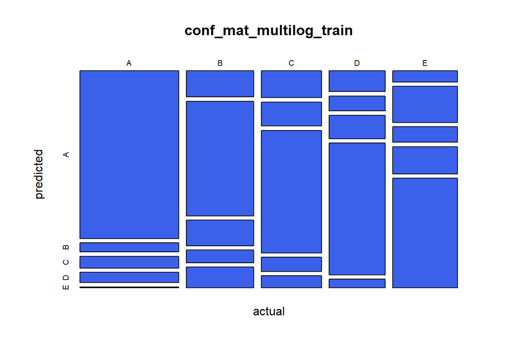

```r
conf_mat_multilog_train <- table(actual = train$classe, predicted = train$pred_multilog)

conf_mat_multilog_test <- table(actual = test$classe, predicted = test$pred_multilog)

plot(conf_mat_multilog_train, color = "#3B61EA")
```

```r
confusionMatrix(conf_mat_multilog_train)
```

```
Confusion Matrix and Statistics

      predicted
actual    A    B    C    D    E
     A 3748  203  260  227   23
     B  400 1759  390  195  319
     C  365  325 1667  193  164
     D  264  191  298 1679  110
     E  162  527  229  398 1601

Overall Statistics

               Accuracy : 0.666
                 95% CI : (0.6585, 0.6734)
    No Information Rate : 0.3146
    P-Value [Acc > NIR] : < 2.2e-16

                  Kappa : 0.5761

 Mcnemar's Test P-Value : < 2.2e-16

Statistics by Class:

                     Class: A Class: B Class: C Class: D Class: E
Sensitivity            0.7589   0.5854   0.5861   0.6237   0.7221
Specificity            0.9337   0.8973   0.9185   0.9336   0.9024
Pos Pred Value         0.8402   0.5743   0.6142   0.6605   0.5489
Neg Pred Value         0.8940   0.9014   0.9093   0.9230   0.9518
Prevalence             0.3146   0.1914   0.1812   0.1715   0.1412
Detection Rate         0.2388   0.1121   0.1062   0.1070   0.1020
Detection Prevalence   0.2842   0.1951   0.1729   0.1619   0.1858
Balanced Accuracy      0.8463   0.7413   0.7523   0.7787   0.8123
```

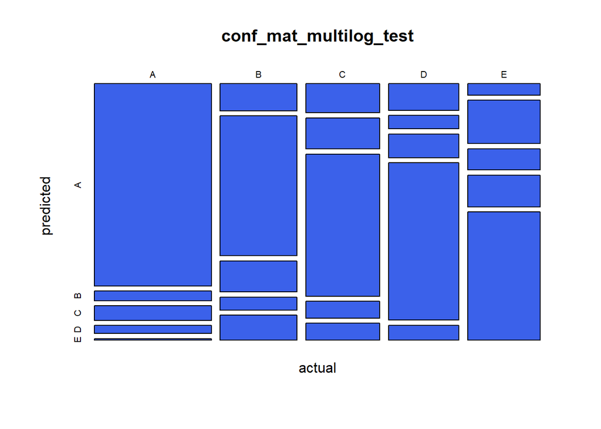

```r
plot(conf_mat_multilog_test, color = "#3B61EA")
```

```r
confusionMatrix(conf_mat_multilog_test)
```

```
Confusion Matrix and Statistics

      predicted
actual   A   B   C   D   E
     A 959  45  69  39   7
     B  84 435  97  40  78
     C  87  93 427  50  51
     D  76  38  68 449  43
     E  33 127  62  93 375

Overall Statistics

               Accuracy : 0.6739
                 95% CI : (0.659, 0.6885)
    No Information Rate : 0.3157
    P-Value [Acc > NIR] : < 2e-16

                  Kappa : 0.5859

 Mcnemar's Test P-Value : 2.2e-12

Statistics by Class:

                     Class: A Class: B Class: C Class: D Class: E
Sensitivity            0.7740   0.5894   0.5906   0.6692  0.67690
Specificity            0.9404   0.9062   0.9122   0.9309  0.90656
Pos Pred Value         0.8570   0.5926   0.6031   0.6662  0.54348
Neg Pred Value         0.9002   0.9050   0.9080   0.9317  0.94467
Prevalence             0.3157   0.1880   0.1842   0.1710  0.14115
Detection Rate         0.2443   0.1108   0.1088   0.1144  0.09554
Detection Prevalence   0.2851   0.1870   0.1804   0.1717  0.17580
Balanced Accuracy      0.8572   0.7478   0.7514   0.8000  0.79173
```

## KNN

```r
model_knn <- train(classe~., data = train, method = "knn")
model_knn
```

```
k-Nearest Neighbors

15697 samples
   53 predictor
    5 classes: 'A', 'B', 'C', 'D', 'E'

No pre-processing
Resampling: Bootstrapped (25 reps)
Summary of sample sizes: 15697, 15697, 15697, 15697, 15697, 15697, ...
Resampling results across tuning parameters:

  k  Accuracy   Kappa
  5  0.8830273  0.8519770
  7  0.8670542  0.8317422
  9  0.8530127  0.8139523

Accuracy was used to select the optimal model using the largest value.
The final value used for the model was k = 5.
```

### Accuracy measures

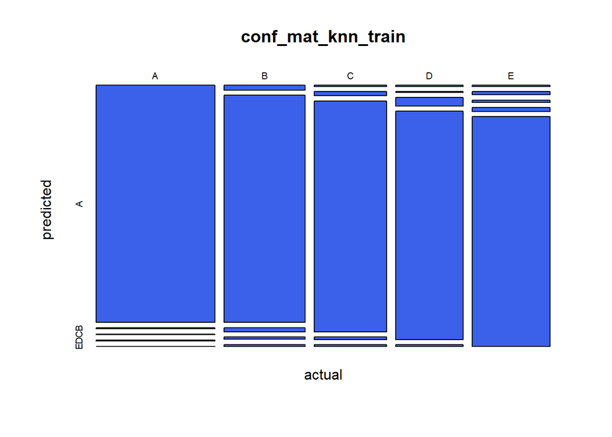

```r
train$pred_knn <- predict(model_knn, newdata = train)

conf_mat_knn_train <- table(actual = train$classe,
                               predicted = train$pred_knn)

plot(conf_mat_knn_train, color = "#3B61EA")
```

```r
confusionMatrix(conf_mat_knn_train)
```

```
Confusion Matrix and Statistics

      predicted
actual    A    B    C    D    E
     A 4402   19   15   21    4
     B   62 2893   52   29   27
     C   12   46 2608   28   20
     D   12    6   90 2416   18
     E   13   39   27   47 2791

Overall Statistics

               Accuracy : 0.9626
                 95% CI : (0.9595, 0.9655)
    No Information Rate : 0.2867
    P-Value [Acc > NIR] : < 2.2e-16

                  Kappa : 0.9527

 Mcnemar's Test P-Value : 6.524e-16

Statistics by Class:

                     Class: A Class: B Class: C Class: D Class: E
Sensitivity            0.9780   0.9634   0.9341   0.9508   0.9759
Specificity            0.9947   0.9866   0.9918   0.9904   0.9902
Pos Pred Value         0.9868   0.9445   0.9609   0.9504   0.9568
Neg Pred Value         0.9912   0.9913   0.9858   0.9905   0.9946
Prevalence             0.2867   0.1913   0.1779   0.1619   0.1822
Detection Rate         0.2804   0.1843   0.1661   0.1539   0.1778
Detection Prevalence   0.2842   0.1951   0.1729   0.1619   0.1858
Balanced Accuracy      0.9864   0.9750   0.9629   0.9706   0.9830
```

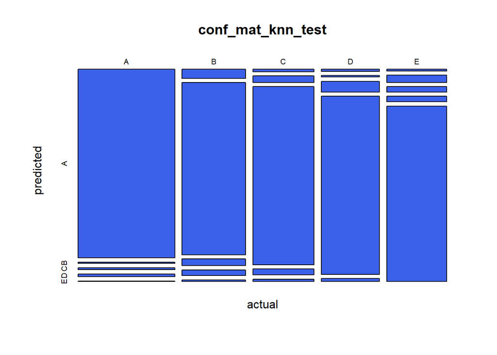

```r
test$pred_knn <- predict(model_knn, newdata = test)

conf_mat_knn_test <- table(actual = test$classe,
                                 predicted = test$pred_knn)

plot(conf_mat_knn_test, color = "#3B61EA")
```

```r
confusionMatrix(conf_mat_knn_test)
```

```
Confusion Matrix and Statistics

      predicted
actual    A    B    C    D    E
     A 1081    7   12   16    3
     B   34  647   25   22    6
     C    9   23  646   21    9
     D    7    5   37  615   10
     E    6   25   19   20  620

Overall Statistics

               Accuracy : 0.9195
                 95% CI : (0.9105, 0.9278)
    No Information Rate : 0.2897
    P-Value [Acc > NIR] : < 2.2e-16

                  Kappa : 0.8981

 Mcnemar's Test P-Value : 1.668e-08

Statistics by Class:

                     Class: A Class: B Class: C Class: D Class: E
Sensitivity            0.9507   0.9151   0.8742   0.8862   0.9568
Specificity            0.9864   0.9730   0.9805   0.9817   0.9786
Pos Pred Value         0.9660   0.8815   0.9124   0.9125   0.8986
Neg Pred Value         0.9800   0.9812   0.9711   0.9757   0.9913
Prevalence             0.2897   0.1801   0.1883   0.1768   0.1651
Detection Rate         0.2754   0.1648   0.1646   0.1567   0.1580
Detection Prevalence   0.2851   0.1870   0.1804   0.1717   0.1758
Balanced Accuracy      0.9686   0.9440   0.9273   0.9340   0.9677
```

## Decision Trees

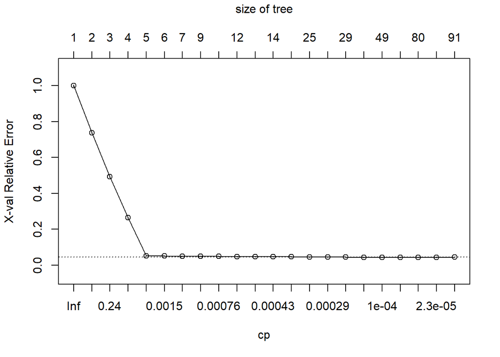

```r
model_dc <- rpart(classe~., data = train, method = "class",
                control = rpart.control(cp = 0))

plotcp(model_dc)
```

```r
printcp(model_dc)
```

```
Classification tree:
rpart(formula = classe ~ ., data = train, method = "class", control = rpart.control(cp = 0))

Variables actually used in tree construction:
 [1] accel_arm_y       accel_arm_z       accel_belt_x      accel_dumbbell_z
 [5] accel_forearm_x   accel_forearm_y   accel_forearm_z   gyros_arm_x
 [9] gyros_arm_y       gyros_arm_z       gyros_belt_z      gyros_dumbbell_x
[13] gyros_dumbbell_y  gyros_forearm_x   gyros_forearm_y   magnet_arm_x
[17] magnet_arm_y      magnet_belt_x     magnet_belt_y     magnet_belt_z
[21] magnet_dumbbell_x magnet_dumbbell_y magnet_dumbbell_z magnet_forearm_y
[25] pitch_belt        pitch_dumbbell    pitch_forearm     pred_knn
[29] pred_multilog     roll_belt         roll_forearm      total_accel_arm
[33] yaw_arm           yaw_belt          yaw_dumbbell      yaw_forearm

Root node error: 11236/15697 = 0.71581
```

[output cut: 26 more lines]

### Pruning

Pruning a decision tree based on complexity parameter allows to extract better results from a decision tree model.

```r
model_dc_pruned <- prune(model_dc, cp = 2.2799e-04)
rm(model_dc)
```

### Accuracy Measures

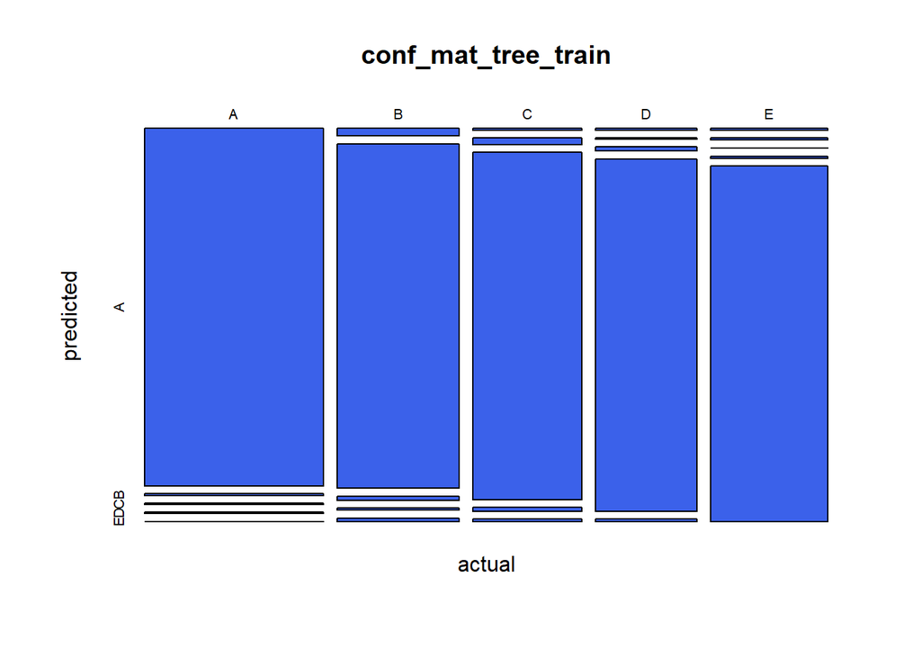

```r
train$pred_dc <- predict(model_dc_pruned, newdata = train, type = "class")

conf_mat_tree_train <- table(actual = train$classe,
                                predicted = train$pred_dc)

plot(conf_mat_tree_train, color = "#3B61EA")
```

```r
confusionMatrix(conf_mat_tree_train)
```

```
Confusion Matrix and Statistics

      predicted
actual    A    B    C    D    E
     A 4406   23   10   18    4
     B   64 2914   37   16   32
     C   13   48 2605   28   20
     D   12    6   29 2476   19
     E   13   16    3   19 2866

Overall Statistics

               Accuracy : 0.9726
                 95% CI : (0.9699, 0.9751)
    No Information Rate : 0.2872
    P-Value [Acc > NIR] : < 2.2e-16

                  Kappa : 0.9653

 Mcnemar's Test P-Value : 3.211e-07

Statistics by Class:

                     Class: A Class: B Class: C Class: D Class: E
Sensitivity            0.9774   0.9691   0.9706   0.9683   0.9745
Specificity            0.9951   0.9883   0.9916   0.9950   0.9960
Pos Pred Value         0.9877   0.9514   0.9598   0.9740   0.9825
Neg Pred Value         0.9909   0.9926   0.9939   0.9938   0.9941
Prevalence             0.2872   0.1916   0.1710   0.1629   0.1874
Detection Rate         0.2807   0.1856   0.1660   0.1577   0.1826
Detection Prevalence   0.2842   0.1951   0.1729   0.1619   0.1858
Balanced Accuracy      0.9862   0.9787   0.9811   0.9816   0.9853
```

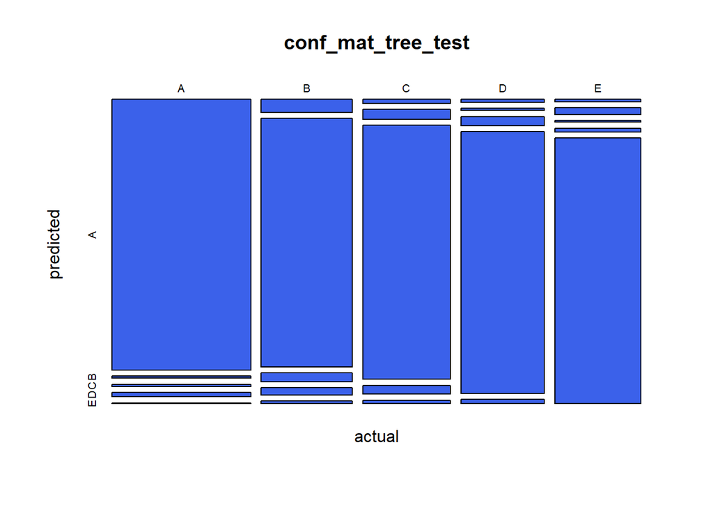

```r
test$pred_dc <- predict(model_dc_pruned, newdata = test, type = "class")

conf_mat_tree_test <- table(actual = test$classe,
                           predicted = test$pred_dc)

plot(conf_mat_tree_test, color = "#3B61EA")
```

```r
confusionMatrix(conf_mat_tree_test)
```

```
Confusion Matrix and Statistics

      predicted
actual    A    B    C    D    E
     A 1082    8    9   17    3
     B   34  651   23   19    7
     C   10   25  642   22    9
     D    7    5   22  630   10
     E    6   16    4    9  655

Overall Statistics

               Accuracy : 0.9325
                 95% CI : (0.9242, 0.9401)
    No Information Rate : 0.2902
    P-Value [Acc > NIR] : < 2.2e-16

                  Kappa : 0.9146

 Mcnemar's Test P-Value : 0.0001219

Statistics by Class:

                     Class: A Class: B Class: C Class: D Class: E
Sensitivity            0.9500   0.9234   0.9171   0.9039   0.9576
Specificity            0.9867   0.9742   0.9795   0.9864   0.9892
Pos Pred Value         0.9669   0.8869   0.9068   0.9347   0.9493
Neg Pred Value         0.9797   0.9831   0.9820   0.9794   0.9910
Prevalence             0.2902   0.1796   0.1783   0.1776   0.1743
Detection Rate         0.2757   0.1659   0.1636   0.1605   0.1669
Detection Prevalence   0.2851   0.1870   0.1804   0.1717   0.1758
Balanced Accuracy      0.9683   0.9488   0.9483   0.9451   0.9734
```

## Ensemble Method: Random Forest

```r
model_rf <- randomForest(formula = classe~., data = train, ntree = 500)
```

### Accuracy Measures

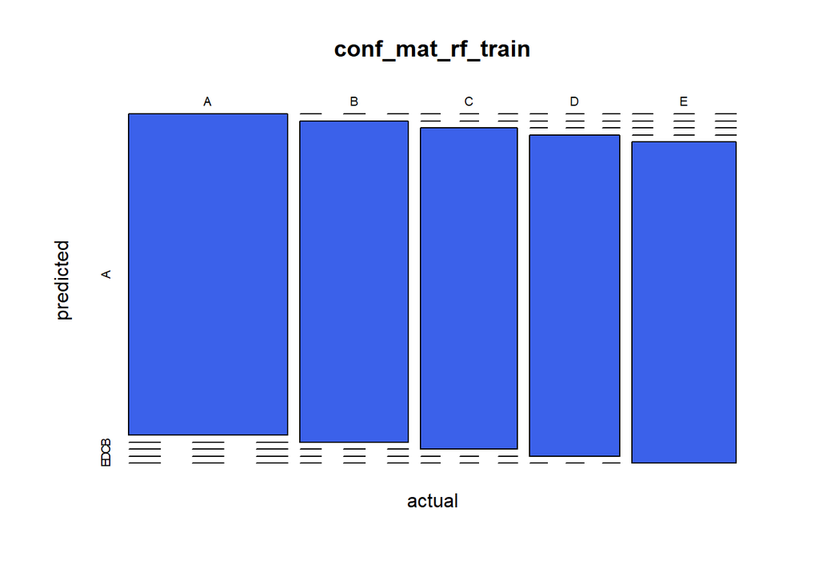

```r
train$pred_rf <- predict(model_rf, newdata = train)
conf_mat_rf_train <- table(actual = train$classe, predicted = train$pred_rf)

plot(conf_mat_rf_train, color = "#3B61EA")
```

```r
confusionMatrix(conf_mat_rf_train)
```

```
## Confusion Matrix and Statistics
##
##       predicted
## actual    A    B    C    D    E
##      A 4461    0    0    0    0
##      B    0 3063    0    0    0
##      C    0    0 2714    0    0
##      D    0    0    0 2542    0
##      E    0    0    0    0 2917
##
## Overall Statistics
##
##                Accuracy : 1
##                  95% CI : (0.9998, 1)
##     No Information Rate : 0.2842
##     P-Value [Acc > NIR] : < 2.2e-16
##
##                   Kappa : 1
##
##  Mcnemar's Test P-Value : NA
##
## Statistics by Class:
##
##                      Class: A Class: B Class: C Class: D Class: E
## Sensitivity            1.0000   1.0000   1.0000   1.0000   1.0000
## Specificity            1.0000   1.0000   1.0000   1.0000   1.0000
## Pos Pred Value         1.0000   1.0000   1.0000   1.0000   1.0000
## Neg Pred Value         1.0000   1.0000   1.0000   1.0000   1.0000
## Prevalence             0.2842   0.1951   0.1729   0.1619   0.1858
## Detection Rate         0.2842   0.1951   0.1729   0.1619   0.1858
## Detection Prevalence   0.2842   0.1951   0.1729   0.1619   0.1858
## Balanced Accuracy      1.0000   1.0000   1.0000   1.0000   1.0000
```

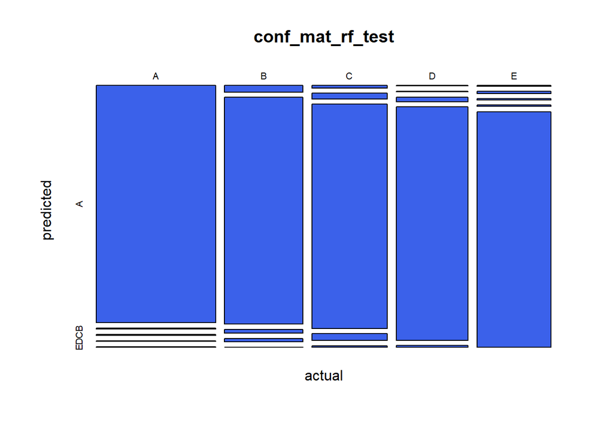

```r
test$pred_rf <- predict(model_rf, newdata = test)
conf_mat_rf_test <- table(actual = test$classe, predicted = test$pred_rf)

plot(conf_mat_rf_test, color = "#3B61EA")
```

```r
confusionMatrix(conf_mat_rf_test)
```

```
## Confusion Matrix and Statistics
##
##       predicted
## actual    A    B    C    D    E
##      A 1102    5    6    3    3
##      B   20  691   12   10    1
##      C    7   17  659   20    5
##      D    1    2   13  653    5
##      E    2    6    3    4  675
##
## Overall Statistics
##
##                Accuracy : 0.9631
##                  95% CI : (0.9567, 0.9687)
##     No Information Rate : 0.2884
##     P-Value [Acc > NIR] : < 2e-16
##
##                   Kappa : 0.9533
##
##  Mcnemar's Test P-Value : 0.01441
##
## Statistics by Class:
##
##                      Class: A Class: B Class: C Class: D Class: E
## Sensitivity            0.9735   0.9584   0.9509   0.9464   0.9797
## Specificity            0.9939   0.9866   0.9848   0.9935   0.9954
## Pos Pred Value         0.9848   0.9414   0.9308   0.9688   0.9783
## Neg Pred Value         0.9893   0.9906   0.9894   0.9886   0.9957
## Prevalence             0.2884   0.1837   0.1766   0.1758   0.1755
## Detection Rate         0.2808   0.1761   0.1679   0.1664   0.1720
## Detection Prevalence   0.2851   0.1870   0.1804   0.1717   0.1758
## Balanced Accuracy      0.9837   0.9725   0.9679   0.9699   0.9875
```

# Conclusion

The random forest classifier produced the highest overall accuracy among the tested models, demonstrating its resilience while processing high-dimensional, complicated data, such accelerometer measurements from several sensors. This is in line with findings in scholarly literature that highlight the applicability of random forests for wearable data because of their capacity to manage heterogeneous feature sets and their resistance to overfitting (Rodgers et al., 2019; Wickham, 2019). The project also emphasizes the significance of feature engineering and data preprocessing, which were essential for removing duplicate or unnecessary data and improving model performance. Kuhn and Johnson (2019) confirmed this procedure in their work on feature selection.

The project’s insights have important ramifications for applications in healthcare. By enabling medical personnel to precisely watch patient development and take swift action when aberrations in exercise form are identified, remote exercise quality monitoring has the potential to completely transform physical therapy and rehabilitation. By spotting unusual movement patterns that could point to the early stages of musculoskeletal problems, this method can be applied to preventive care (Bejarano et al., 2014). Additionally, wearable sensor data combined with R-based analytics presents a feasible solution for remote patient monitoring as telehealth gains traction, especially in the wake of the COVID-19 pandemic.

All things considered, this study shows how R-based analytics can greatly improve our capacity to decipher and respond to human activity data in healthcare settings when applied to wearable sensor data. Analytics-driven insights can assist therapeutic interventions and preventive measures by enabling accurate and continuous tracking of patient activities, which can lead to better health outcomes and a more individualized approach to care. Neural networks may provide even more detailed insights from wearable data, thus future studies might investigate incorporating deep learning techniques for activity detection. The generalizability of these models might also be strengthened by extending this analysis to encompass a larger demographic sample and a greater range of activities, opening the door for their use in many health scenarios. As a result, this initiative establishes the foundation for applied analytics in wearable technology, highlighting its revolutionary potential in contemporary healthcare.

# References

Bejarano, N. C., Ambrosini, E., Pedrocchi, A., Ferrigno, G., Monticone, M., & Ferrante, S. (2014). A novel adaptive, real-time algorithm to detect gait events from wearable sensors. IEEE transactions on neural systems and rehabilitation engineering, 23(3), 413-422.

Breiman, L. (2001). Random forests. Machine learning, 45, 5-32.

Kuhn, M. (2008). Building predictive models in R using the caret package. Journal of statistical software, 28, 1-26.

Kuhn, M. (2013). Applied predictive modeling.

Kuhn, M., & Johnson, K. (2019). Feature engineering and selection: A practical approach for predictive models. Chapman and Hall/CRC

Mukhopadhyay, S. C. (2014). Wearable sensors for human activity monitoring: A review. IEEE sensors journal, 15(3), 1321-1330.

Piwek, L., Ellis, D. A., Andrews, S., & Joinson, A. (2016). The rise of consumer health wearables: promises and barriers. PLoS medicine, 13(2), e1001953.

Rodgers, M. M., Alon, G., Pai, V. M., & Conroy, R. S. (2019). Wearable technologies for active living and rehabilitation: Current research challenges and future opportunities. Journal of rehabilitation and assistive technologies engineering, 6, 2055668319839607.

Therneau, T. M., & Atkinson, E. J. (1997). An introduction to recursive partitioning using the RPART routines (Vol. 61, p. 452). Mayo Foundation: Technical report.

Venables, W. N., & Ripley, B. D. (2013). Modern applied statistics with S-PLUS. Springer Science & Business Media.

Wang, S., Yang, J., Chen, N., Chen, X., & Zhang, Q. (2005, October). Human activity recognition with user-free accelerometers in the sensor networks. In 2005 International Conference on Neural Networks and Brain (Vol. 2, pp. 1212-1217). IEEE.

Wickham, H. (2019). Advanced r. chapman and hall/CRC.